# R Notebook

```r
library(readxl)
library(tidyr)
library(dplyr)
library(arrow)
library(ggplot2)
library(dplyr)
library(zoo)

setwd('C:/Users/DBT3KD/Desktop/Etude_macro_elec/DATA/gas_news_data')
# Import the functions from 'my_functions.R'
Sys.setenv(lang = "en_US")

news_data <- read_parquet("sorted_news_data.parquet")
```

Etant donné le corpus qui grossit au cours du temps, J’ai besoin d’un benchmark qui permet de normaliser le nombre de nouvelles par jour.

```r
print(class(news_data$datetime))
```

```
[1] "POSIXct" "POSIXt"
```

Try to detect and affirmative structure in the news titles

```r
#library(spacyr)

# Initialize spacyr (make sure spaCy is installed in your environment)
# Install spaCy (this might take a few minutes)
# spacy_install()
# spacy_initialize()
#
# # Function to check if a sentence has an affirmative structure
# is_affirmative_structure <- function(sentence) {
#   # Parse the sentence
#   parsed <- spacy_parse(sentence)
#
#   # Look for basic SVO structure (subject-verb-object)
#   has_subject <- FALSE
#   has_verb <- FALSE
#
#   for (i in 1:nrow(parsed)) {
#     # Check if the word is a noun and acts as a subject
#     if (parsed$pos[i] == "NOUN") {
#       has_subject <- TRUE
#     }
#     # Check if there is a verb following the noun subject
#     if (has_subject && parsed$pos[i] == "VERB") {
#       has_verb <- TRUE
#       break
#     }
#   }
#
#   # Return TRUE if both subject and verb are present, indicating an affirmative structure
#   return(has_subject && has_verb)
# }
#
# # Example usage
# sentence <- "PA Might See Lower Gas Prices In 2024"
# is_affirmative_structure(sentence)
```

Browsing the news titles, you can assess that the news titles are not very reliable. Sometimes the connection with supply or demand is weak, sometimes it is obviously wrong.

Thus, I filter again my news corpus by keywords

```r
setwd('C:/Users/DBT3KD/Desktop/Etude_macro_elec/DATA/gas_news_data')
labeled_news <- rbind(demand_filtered_news, supply_filtered_news, uncertainty_filtered_news)%>% arrange(datetime)

write_parquet(labeled_news , "labeled_news_data.parquet")

setwd('C:/Users/DBT3KD/Desktop/Etude_macro_elec/')
write.csv(labeled_news, "labeled_news_data.csv")


full_news_count <- labeled_news %>%
  select(media, datetime) %>%
  distinct() %>%
  group_by(datetime) %>%
  summarise(news_per_day = n())

event_news_count <- labeled_news %>%
  select(media, datetime, event_type) %>%
  distinct() %>%
  group_by(datetime, event_type) %>%
  summarise(news_per_day = n())
```

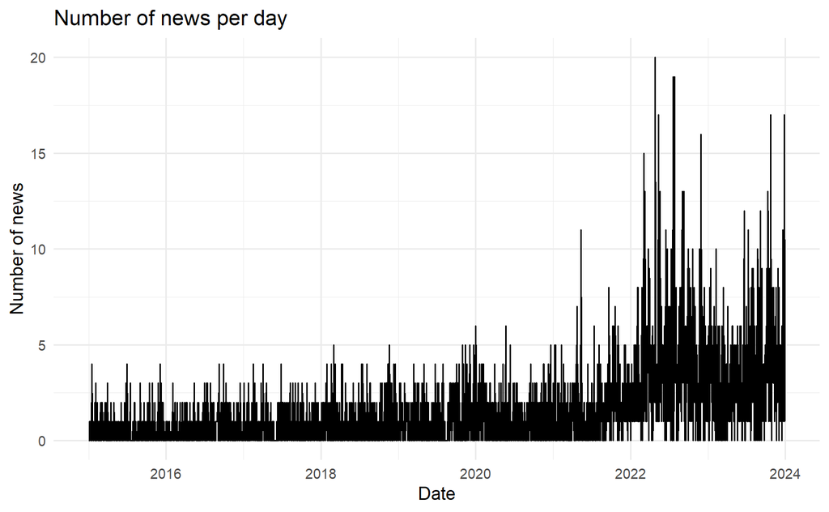

```r
full_dates <- tibble(datetime = seq(min(news_data$datetime, na.rm=TRUE), max(news_data$datetime, na.rm=TRUE), by = "day"))

# Fusionner le DataFrame original avec la séquence complète de dates
complete_data <- full_dates %>%
  left_join(full_news_count , by = "datetime") %>%
  replace_na(list(news_per_day = 0))


ggplot(complete_data, aes(x = datetime, y = news_per_day)) +
  geom_line() +
  labs(title = "Number of news per day",
       x = "Date",
       y = "Number of news") +
  theme_minimal()
```

On fait de même en ayant classé les news par thème

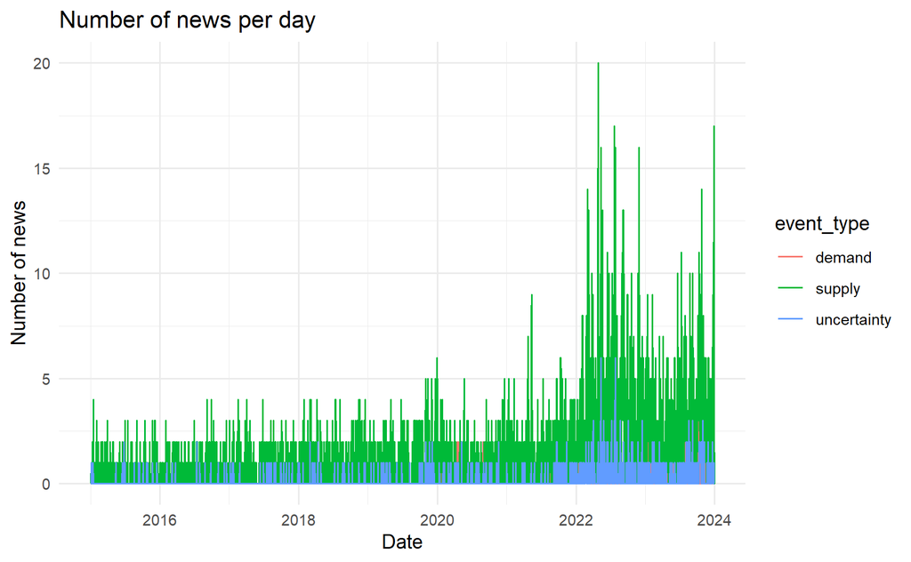

```r
# Créer un dataframe avec les types d'événements
event_types <- data.frame(event_type = c("supply", "demand", "uncertainty"))

# Créer toutes les combinaisons de dates et d'événements
full_event_dates <- full_dates %>%
  crossing(event_types)

# Joindre avec les données de nouvelles
event_complete_data <- full_event_dates %>%
  left_join(event_news_count, by = c("datetime", "event_type")) %>%
  replace_na(list(news_per_day = 0))

ggplot(event_complete_data, aes(x = datetime, y = news_per_day, color = event_type)) +
  geom_line() +
  labs(title = "Number of news per day",
       x = "Date",
       y = "Number of news") +
  theme_minimal()
```

On affiche les quelques jours avec le plus de nouvelles

```r
base <- complete_data %>% filter(news_per_day > 0)
base %>%
  group_by(news_per_day) %>%
  mutate(n = n())
```

| datetime | news_per_day | n |
| --- | --- | --- |
| 2015-01-04 | 1 | 927 |
| 2015-01-05 | 1 | 927 |
| 2015-01-06 | 1 | 927 |
| 2015-01-08 | 1 | 927 |
| 2015-01-09 | 1 | 927 |
| 2015-01-12 | 2 | 474 |
| 2015-01-14 | 1 | 927 |
| 2015-01-16 | 4 | 153 |
| 2015-01-17 | 1 | 927 |
| 2015-01-18 | 1 | 927 |

[output cut: 990 more lines]

```r
base %>%
  arrange(desc(news_per_day)) %>%
  slice(1:10)
```

| datetime | news_per_day |
| --- | --- |
| 2022-04-27 | 20 |
| 2022-07-21 | 19 |
| 2022-07-26 | 19 |
| 2022-05-11 | 17 |
| 2023-10-23 | 17 |
| 2023-12-27 | 17 |
| 2022-11-29 | 16 |
| 2022-03-03 | 15 |
| 2022-03-08 | 13 |
| 2022-05-20 | 13 |

```r
#Jun 18, 2014
#Jun 12, 2014
# Northern Iraq offensive

#Feb 23, 2011 oil
#Lybia supply disruptions
```

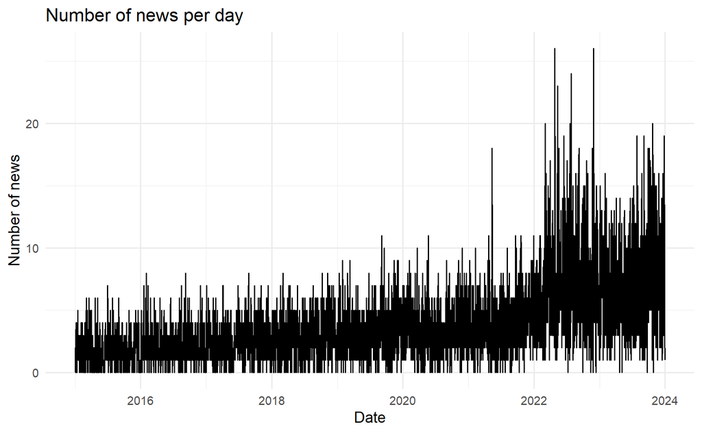

```r
rough_news_count <- filtered_news_distinct %>%
  select(media, datetime, date) %>%
  distinct() %>%
  group_by(datetime, date) %>%
  summarise(news_per_day = n())
full_dates <- tibble(datetime = seq(min(news_data$datetime, na.rm=TRUE), max(news_data$datetime, na.rm=TRUE), by = "day"))

# Fusionner le DataFrame original avec la séquence complète de dates
complete_data <- full_dates %>%
  left_join(rough_news_count , by = "datetime") %>%
  replace_na(list(news_per_day = 0))


ggplot(complete_data, aes(x = datetime, y = news_per_day)) +
  geom_line() +
  labs(title = "Number of news per day",
       x = "Date",
       y = "Number of news") +
  theme_minimal()
```

Il faut se fixer un seuil d’identification des chocs potentiellement variable avec le temps. Une normalisation par rapport à la quantité de news disponibles. Il peut être différent pour les supply and demand, puisqu’il semble qu’il y ait plus de nouvelles de supply que de demand.

```r
shock_data <- event_complete_data %>%
  arrange(datetime) %>%  # Replace 'date_column' with your actual date column name
  mutate(moving_avg_news = rollapply(news_per_day, width = 30, FUN = mean, fill = NA, align = "right"),
        moving_std_news = rollapply(news_per_day, width = 30, FUN = sd, fill = NA, align = "right"),
       binary_shock= (news_per_day >  moving_avg_news + 4*moving_std_news),
       intensity_shock = ifelse(binary_shock, news_per_day/moving_avg_news, 0)
       )

instrument_days <- shock_data %>%
  filter(binary_shock ==TRUE) %>%
  filter(event_type== 'demand' | news_per_day > 2)
```

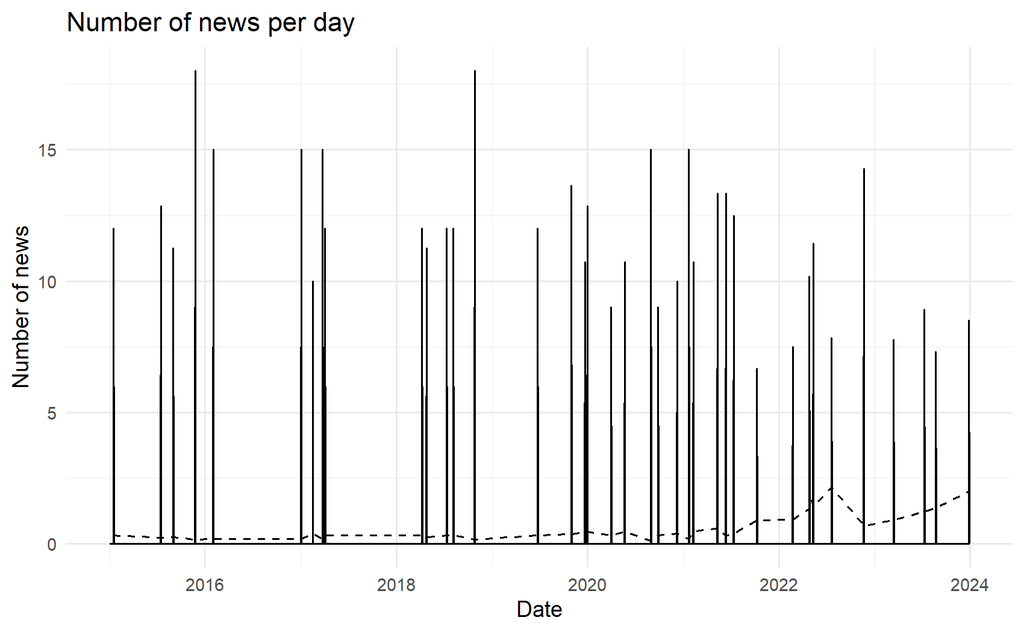

```r
instrument_results <- full_dates %>%
  left_join(instrument_days, by = "datetime") %>%
  mutate(across(where(is.numeric), ~replace_na(., 0)))


ggplot(instrument_days, aes(x = datetime)) +
  geom_line(data= instrument_results, aes(x = datetime, y = intensity_shock)) +
  #geom_line(aes(y = news_per_day), color = 'yellow') +
  geom_line(aes(y = moving_avg_news), linetype='dashed') +
  labs(title = "Number of news per day",
       x = "Date",
       y = "Number of news") +
  theme_minimal()
```

```r
save_var_path <- 'C:/Users/DBT3KD/Desktop/Etude_macro_elec/prix_electricite_gitlab/VAR_analysis/VAR_output'
setwd(save_var_path)
write_parquet(instrument_results, "instrument_news_shock.parquet")
```

```r
setwd('C:/Users/DBT3KD/Desktop/Etude_macro_elec/DATA/gas_news_data')
gas_instrument_data <-read_parquet("gas_instrument_data.parquet")
surprise_serie <- read_parquet("surprise_serie.parquet")


setwd('C:/Users/DBT3KD/Desktop/Etude_macro_elec/DATA/gas_news_data')
events_data <- read.csv("alex_gassani_shocks.csv")

events_data_serie <- events_data %>%
  mutate(month = month(Date), year= year(Date))%>%
  group_by(month, year) %>%
  summarize(Value= sum(Value), Date = first(Date)) %>%
  arrange(Date)
events_data_serie
```

| month | year | Value | Date |
| --- | --- | --- | --- |
| 3 | 2011 | 5.6 | 2011-03-14 |
| 3 | 2014 | 9.5 | 2014-03-03 |
| 8 | 2014 | 15.9 | 2014-08-29 |
| 4 | 2016 | -9.6 | 2016-04-28 |
| 9 | 2019 | 17.7 | 2019-09-10 |
| 6 | 2020 | 15.6 | 2020-06-29 |
| 8 | 2020 | 12.9 | 2020-08-03 |
| 10 | 2021 | -14.2 | 2021-10-05 |
| 2 | 2022 | 20.4 | 2022-02-24 |
| 3 | 2022 | 8.4 | 2022-03-02 |

[output cut: 4 more lines]

```r
shock_series_all <- left_join(surprise_serie ,events_data_serie%>% select(-Date), by = c("month", 'year'))
# Remplir les NA avec 0
shock_series_all[is.na(shock_series_all)] <- 0
shock_series_all
```

| month | year | shock | avg_price | Date | Delta | Value |
| --- | --- | --- | --- | --- | --- | --- |
| 1 | 2015 | -1 | 19.380952 | 2015-01-16 | -5.1597052 | 0.0 |
| 1 | 2016 | 0 | 13.300000 | 2016-01-16 | 0.0000000 | 0.0 |
| 1 | 2017 | 0 | 19.272727 | 2017-01-15 | 0.0000000 | 0.0 |
| 1 | 2018 | 0 | 18.136364 | 2018-01-16 | 0.0000000 | 0.0 |
| 1 | 2019 | 0 | 21.136364 | 2019-01-16 | 0.0000000 | 0.0 |
| 1 | 2020 | 0 | 10.636364 | 2020-01-17 | 0.0000000 | 0.0 |
| 1 | 2021 | 0 | 20.000000 | 2021-01-16 | 0.0000000 | 0.0 |
| 1 | 2022 | 0 | 84.714286 | 2022-01-16 | 0.0000000 | 0.0 |
| 1 | 2023 | 0 | 63.454545 | 2023-01-15 | 0.0000000 | 0.0 |
| 2 | 2015 | 0 | 21.750000 | 2015-02-14 | 0.0000000 | 0.0 |

[output cut: 98 more lines]

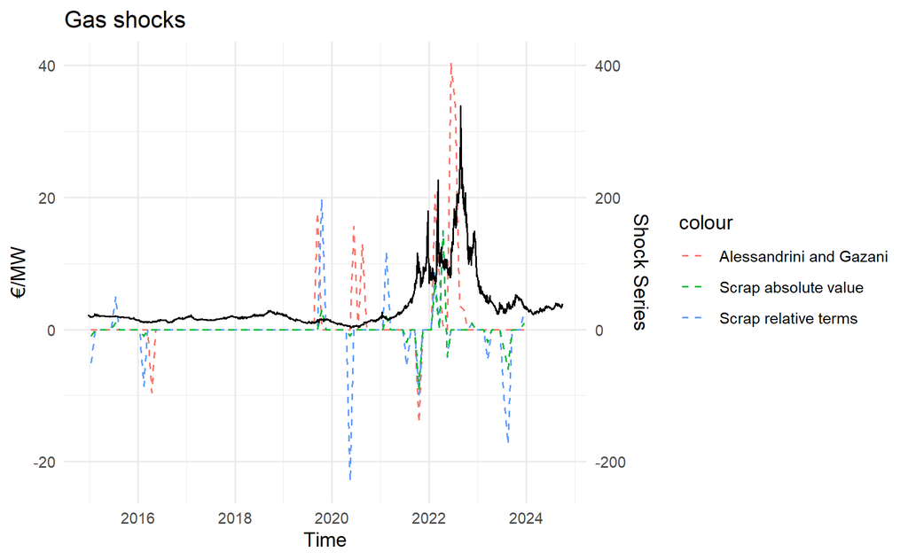

```r
my_plot <- ggplot()+
  geom_line(data= shock_series_all, aes(x= as.POSIXct.Date(Date) , y= Value, color='Alessandrini and Gazani'), linetype = 'dashed')+
  geom_line(data = shock_series_all, aes(x=as.POSIXct.Date(Date), y=Delta, color='Scrap relative terms'), linetype = 'dashed')+
  geom_line(data = shock_series_all, aes(x=as.POSIXct.Date(Date), y=shock, color='Scrap absolute value'), linetype = 'dashed')+
  labs(title = 'Gas shocks',
      x = "Time") +
  geom_line(data=gas_data_tot[1:(nrow(gas_data_tot)-600),], aes(x=time, y= Gas_TTF/10) )+
  theme_minimal() +
  scale_y_continuous(
    name = "€/MW",
    sec.axis = sec_axis(~ . * 10, name = "Shock Series")  # Adjust scaling factor if needed
  )

my_plot
```

On cherche à vérifier si les variations de prix sont plus importantes les jours indiqués par l’instrument par rapport aux jours lambdas

```r
fluct_abs_gas_normales <-  gas_instrument_data %>%
  filter(binary_shock == FALSE) %>%
  pull(shock_serie) %>%
  sd(na.rm = TRUE)

fluct_abs_gas_news <- gas_instrument_data %>%
  filter(binary_shock == TRUE) %>%
  pull(shock_serie) %>%
  sd(na.rm = TRUE)

print(fluct_abs_gas_normales)
```

```
[1] 4.571104
```

```r
print(fluct_abs_gas_news)
```

```
[1] 3.279738
```

Pour l’instant Alessandri and Gassani arrive à mieux repérer les évènements déterminants sur le marché du gaz.

```r
sd(fluct_alex_gass$shock_serie)
```

```
[1] 21.26813
```